# Project Python Foundations: FoodHub Data Analysis

### Context

The number of restaurants in New York is increasing day by day. Lots of students and busy professionals rely on those restaurants due to their hectic lifestyles. Online food delivery service is a great option for them. It provides them with good food from their favorite restaurants. A food aggregator company FoodHub offers access to multiple restaurants through a single smartphone app.

The app allows the restaurants to receive a direct online order from a customer. The app assigns a delivery person from the company to pick up the order after it is confirmed by the restaurant. The delivery person then uses the map to reach the restaurant and waits for the food package. Once the food package is handed over to the delivery person, he/she confirms the pick-up in the app and travels to the customer's location to deliver the food. The delivery person confirms the drop-off in the app after delivering the food package to the customer. The customer can rate the order in the app. The food aggregator earns money by collecting a fixed margin of the delivery order from the restaurants.

### Objective

The food aggregator company has stored the data of the different orders made by the registered customers in their online portal. They want to analyze the data to get a fair idea about the demand of different restaurants which will help them in enhancing their customer experience. Suppose you are hired as a Data Scientist in this company and the Data Science team has shared some of the key questions that need to be answered. Perform the data analysis to find answers to these questions that will help the company to improve the business.

### Data Description

The data contains the different data related to a food order. The detailed data dictionary is given below.

### Data Dictionary

- order_id: Unique ID of the order
- customer_id: ID of the customer who ordered the food
- restaurant_name: Name of the restaurant
- cuisine_type: Cuisine ordered by the customer
- cost_of_the_order: Cost of the order
- day_of_the_week: Indicates whether the order is placed on a weekday or weekend (The weekday is from Monday to Friday and the weekend is Saturday and Sunday)
- rating: Rating given by the customer out of 5
- food_preparation_time: Time (in minutes) taken by the restaurant to prepare the food. This is calculated by taking the difference between the timestamps of the restaurant's order confirmation and the delivery person's pick-up confirmation.
- delivery_time: Time (in minutes) taken by the delivery person to deliver the food package. This is calculated by taking the difference between the timestamps of the delivery person's pick-up confirmation and drop-off information

### Let us start by importing the required libraries

```python
# Installing the libraries with the specified version.
!pip install numpy==1.25.2 pandas==1.5.3 matplotlib==3.7.1 seaborn==0.13.1 -q --user
```

[output not shown]

**Note**:

- After running the above cell, kindly restart the runtime (for Google Colab) or notebook kernel (for Jupyter Notebook), and run all cells sequentially from the next cell.
- On executing the above line of code, you might see a warning regarding package dependencies. This error message can be ignored as the above code ensures that all necessary libraries and their dependencies are maintained to successfully execute the code in **this notebook**.

```python
# import libraries for data manipulation
import numpy as np
import pandas as pd

# import libraries for data visualization
import matplotlib.pyplot as plt
import seaborn as sns
```

### Understanding the structure of the data

```python
# Mounting Google Drive to access source dataset stored in the Drive from this Colab environment for performing the data analysis
from google.colab import drive
drive.mount('/content/drive')
```

```python
print("✅ Reading the source CSV file from the food aggregator company... starting the analytics journey!")
data = pd.read_csv('/content/drive/MyDrive/Great learning Colab Notebooks/foodhub_order.csv')
```

```
✅ Reading the source CSV file from the food aggregator company... starting the analytics journey!
```

```python
##Setting the display options to show all columns of the dataset
pd.set_option('display.max_columns', None)
print("Displaying the first 5 rows of the dataset")
data.head()
```

```
Displaying the first 5 rows of the dataset
```

|  | order_id | customer_id | restaurant_name | cuisine_type | cost_of_the_order | day_of_the_week | rating | food_preparation_time | delivery_time |
| --- | --- | --- | --- | --- | --- | --- | --- | --- | --- |
| 0 | 1477147 | 337525 | Hangawi | Korean | 30.75 | Weekend | Not given | 25 | 20 |
| 1 | 1477685 | 358141 | Blue Ribbon Sushi Izakaya | Japanese | 12.08 | Weekend | Not given | 25 | 23 |
| 2 | 1477070 | 66393 | Cafe Habana | Mexican | 12.23 | Weekday | 5 | 23 | 28 |
| 3 | 1477334 | 106968 | Blue Ribbon Fried Chicken | American | 29.20 | Weekend | 3 | 25 | 15 |
| 4 | 1478249 | 76942 | Dirty Bird to Go | American | 11.59 | Weekday | 4 | 25 | 24 |

### **Question 1:** How many rows and columns are present in the data? [0.5 mark]

```python
# Print dataset dimensions (rows and columns)
rows, cols = data.shape
print(f"The dataset contains {rows} rows and {cols} columns.")
```

```
The dataset contains 1898 rows and 9 columns.
```

#### Observations:

After reading the foodhub_order.csv file, we confirmed that the **dataset contains 1898 rows and 9 columns**.

### **Question 2:** What are the datatypes of the different columns in the dataset? (The info() function can be used) [0.5 mark]

```python
print("the data types of the columns in the given dataset is\n", data.dtypes)
```

```
the data types of the columns in the given dataset is
 order_id                   int64
customer_id                int64
restaurant_name           object
cuisine_type              object
cost_of_the_order        float64
day_of_the_week           object
rating                    object
food_preparation_time      int64
delivery_time              int64
dtype: object
```

#### Observations:

1. **order_id and customer_id** are of **type int64**, indicating they are numerical values. These likely serve as unique keys for orders and customers, respectively.Also shows the relationship between the customer and the order placed
2. **restaurant_name, cuisine_type, day_of_the_week, and rating** are of **type object**, suggesting they contain categorical data. These columns are useful for grouping descriptive analysis.
3. **cost_of_the_order** is of **type float64**, representing numerical values. This column is suitable for statistical data such as calculating averages, totals, and price distributions.
4. **food_preparation_time and delivery_time** are of **type int64**, indicating they are numerical values. These columns likely measure time in minutes and can be used to assess operational team's efficiency or customer experience.
5. The **rating column**, is **typed as object, it may have to converted to a numerical value for our further EDA to view required insights**

### **Question 3:** Are there any missing values in the data? If yes, treat them using an appropriate method. [1 mark]

```python
###This code extracts and displays the unique values from each column in a DataFrame as a summary table.
# Create a list to store unique values for each column
unique_data = []

# Iterate through all columns and get unique values
for col in data.columns:
    unique_vals = data[col].unique()
    unique_data.append({'Column': col, 'Unique Values': unique_vals})

# Convert the list to a DataFrame
unique_df = pd.DataFrame(unique_data)

# Display the DataFrame
print("Unique values in each column:")
display(unique_df)
```

```
Unique values in each column:
```

|  | Column | Unique Values |
| --- | --- | --- |
| 0 | order_id | [1477147, 1477685, 1477070, 1477334, 1478249, ... |
| 1 | customer_id | [337525, 358141, 66393, 106968, 76942, 147468,... |
| 2 | restaurant_name | [Hangawi, Blue Ribbon Sushi Izakaya, Cafe Haba... |
| 3 | cuisine_type | [Korean, Japanese, Mexican, American, Indian, ... |
| 4 | cost_of_the_order | [30.75, 12.08, 12.23, 29.2, 11.59, 25.22, 6.07... |
| 5 | day_of_the_week | [Weekend, Weekday] |
| 6 | rating | [Not given, 5, 3, 4] |
| 7 | food_preparation_time | [25, 23, 20, 28, 33, 21, 29, 34, 24, 30, 35, 3... |
| 8 | delivery_time | [20, 23, 28, 15, 24, 21, 30, 26, 22, 17, 25, 1... |

```python
###This code cleans the 'rating' column by replacing 'not given' entries with NaN, and converting rating values to numerical variable unlike object type for further EDA
# Replace 'Not given' with NaN and convert the 'rating' column to numerical variable namely float
data['rating'] = data['rating'].replace('Not given', np.nan)
data['rating'] = pd.to_numeric(data['rating'])

# Check the unique values and data type after conversion
print("Unique values in 'rating' after treatment:", data['rating'].unique())
print("Data type of 'rating' after treatment:", data['rating'].dtype)
```

```
Unique values in 'rating' after treatment: [nan  5.  3.  4.]
Data type of 'rating' after treatment: float64
```

#### Observations:

Columns order_id, customer_id, restaurant_name, cuisine_type, cost_of_the_order, day_of_the_week, food_preparation_time, delivery_time contain valid values upon extracting their unique entries. These columns appear to be identifiers with no missing or placeholder values.

**Column rating contains the string value 'not given', which indicates that ratings were not provided by some customers who placed orders**. This **suggests the presence of missing values in the rating column**, represented as a placeholder string rather than standard NaN.

### **Question 4:** Check the statistical summary of the data. What is the minimum, average, and maximum time it takes for food to be prepared once an order is placed? [2 marks]

```python
### Calculate and display basic statistics for food preparation time.
# This code finds the minimum, average, and maximum time (in minutes)
# it takes to prepare food from the 'food_preparation_time' column.

min_time = data['food_preparation_time'].min()
avg_time = data['food_preparation_time'].mean()
max_time = data['food_preparation_time'].max()

print(f"Minimum preparation time: {min_time} minutes")
print(f"Average preparation time: {avg_time:.2f} minutes")
print(f"Maximum preparation time: {max_time} minutes")
```

```
Minimum preparation time: 20 minutes
Average preparation time: 27.37 minutes
Maximum preparation time: 35 minutes
```

#### Observations:

The **minimum preparation time recorded is 20 minutes**, indicating the fastest turnaround for food orders in the dataset.

The **maximum preparation time is 35 minutes**, which may reflect dishes that requires more preparation time or peak-hour delays.

### **Question 5:** How many orders are not rated? [1 mark]

```python
# Count the number of orders filled with NaN in the rating column
na_ratings_count = data['rating'].isna().sum()
print(f"Number of orders not rated: {na_ratings_count}")
```

```
Number of orders not rated: 736
```

#### Observations:

**There are a total of 736 orders in the dataset that were not rated by the customer**. This indicates that a significant portion of customers chose not to provide feedback.

To ensure consistency and enable effective exploratory data analysis (EDA), **we are treating these unrated entries as missing values by converting the placeholder 'not given' to standard NaN.**

**These missing ratings may be imputed further** using appropriate techniques such as filling with the mode, mean depending on the analytical goals only if needed.

### Exploratory Data Analysis (EDA)

### **Question 6:** Explore all the variables and provide observations on their distributions. (Generally, histograms, boxplots, countplots, etc. are used for univariate exploration.) [9 marks]

**Analyse Numerical columns**

**Reasoning**: Creating histograms and boxplots for numerical value columns to understand their distribution

cost of the order, food preparation time, delivery time column analysis

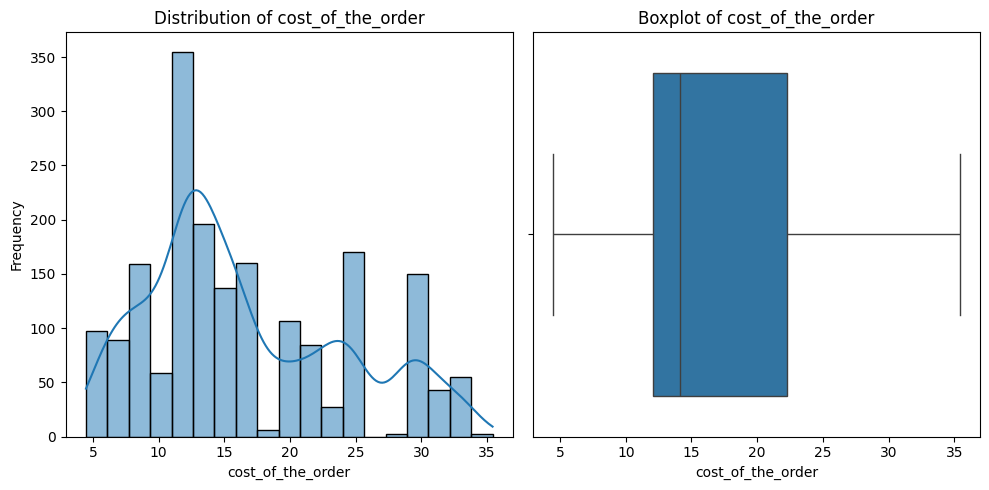

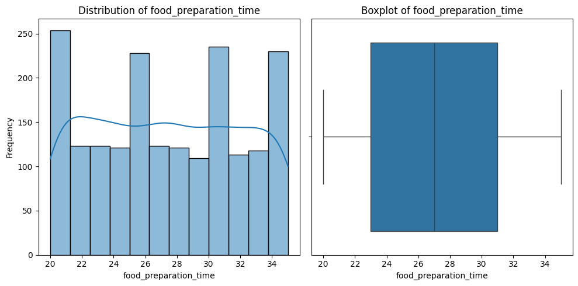

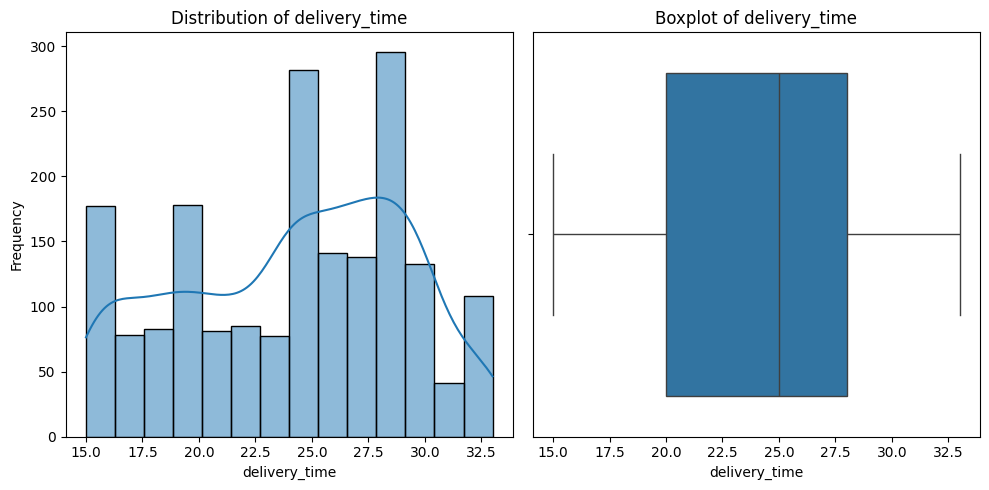

```python
#This code iterates through selected numerical columns to generate side-by-side histograms and boxplots, visualizing their distributions and outliers.
#Each of the column is analyzed independently as its an 'Univariate Analysis'

numerical_cols = ['cost_of_the_order', 'food_preparation_time', 'delivery_time']

for col in numerical_cols:
    plt.figure(figsize=(10, 5))

    plt.subplot(1, 2, 1)
    sns.histplot(data[col], kde=True)
    plt.title(f'Distribution of {col}')
    plt.xlabel(col)
    plt.ylabel('Frequency')

    plt.subplot(1, 2, 2)
    sns.boxplot(x=data[col])
    plt.title(f'Boxplot of {col}')
    plt.xlabel(col)

    plt.tight_layout()
    plt.show()
```

**Analyse Categorical columns** Create barplots for categorical columns to visualize the frequency of each category.

**Restaurant Name Distribution Analysis**

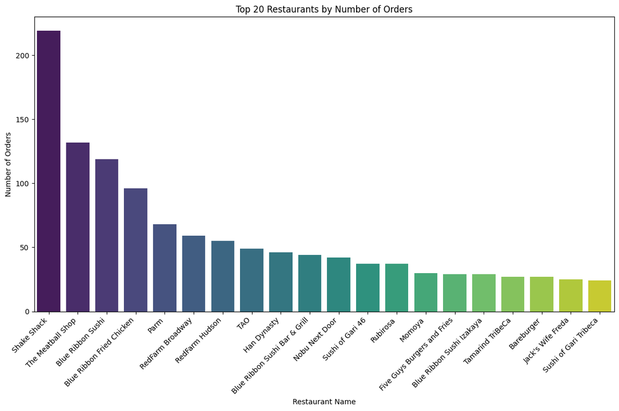

```python
#This code iterates through selected categorical column namely restaurant name to generate a bar plot, visualizing the top 20 restaurants based on their value counts
# Get the top N restaurants by order count. We are presenting the top 20 restaurants with the highest number of orders in the descending order.
top_n = 20  # You can adjust this number to show more or fewer restaurants
top_restaurants = data['restaurant_name'].value_counts().nlargest(top_n)

plt.figure(figsize=(12, 8))
sns.barplot(x=top_restaurants.index, y=top_restaurants.values, palette='viridis', hue=top_restaurants.index, legend=False)
plt.title(f'Top {top_n} Restaurants by Number of Orders')
plt.xlabel('Restaurant Name')
plt.ylabel('Number of Orders')
plt.xticks(rotation=45, ha='right')
plt.tight_layout()
plt.show()
```

**plots for cuisine_type, day of the week are as below**

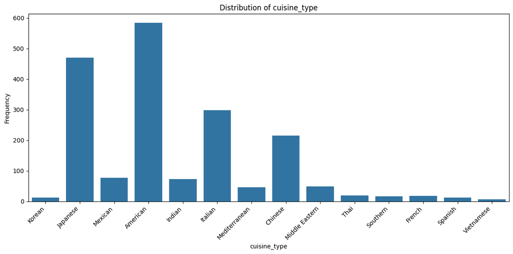

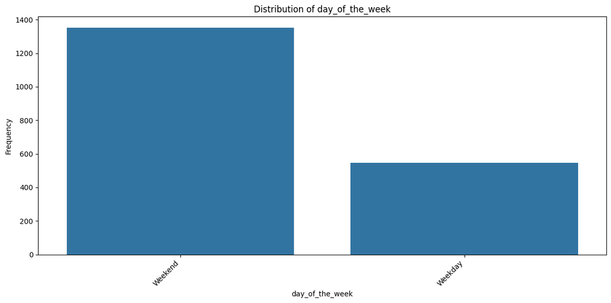

```python
categorical_cols = ['cuisine_type', 'day_of_the_week']

for col in categorical_cols:
    plt.figure(figsize=(12, 6))
    sns.countplot(data=data, x=col)
    plt.title(f'Distribution of {col}')
    plt.xlabel(col)
    plt.ylabel('Frequency')
    plt.xticks(rotation=45, ha='right')
    plt.tight_layout()
    plt.show()
```

Address the 'rating' column with nan values Since the 'rating' column has been identified as having placeholder values and will be converted to numerical, analyze its distribution appropriately after conversion.

**Reasoning**: Replace 'Not given' ratings with NaN and convert the column to numeric, then create a histogram and boxplot to visualize the distribution.

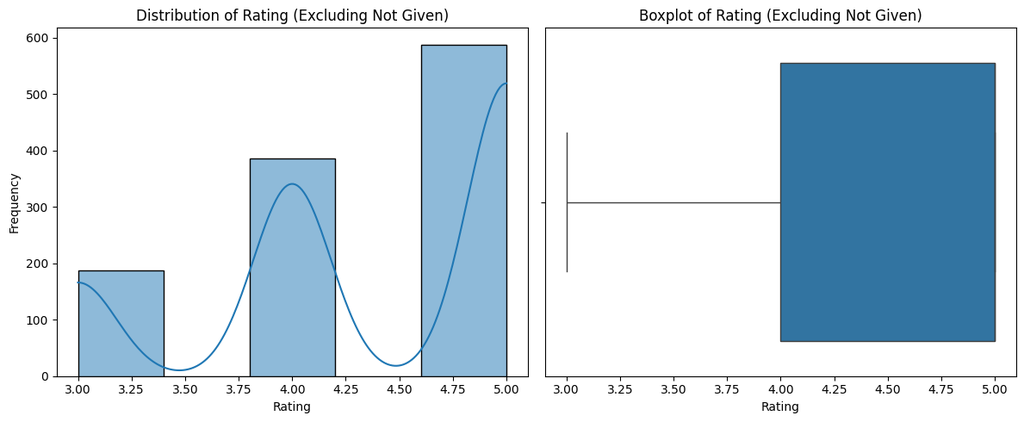

```python
data['rating'] = data['rating'].replace('Not given', np.nan)
data['rating'] = pd.to_numeric(data['rating'])

plt.figure(figsize=(12, 5))

plt.subplot(1, 2, 1)
sns.histplot(data['rating'].dropna(), kde=True, bins=5)
plt.title('Distribution of Rating (Excluding Not Given)')
plt.xlabel('Rating')
plt.ylabel('Frequency')

plt.subplot(1, 2, 2)
sns.boxplot(x=data['rating'].dropna())
plt.title('Boxplot of Rating (Excluding Not Given)')
plt.xlabel('Rating')

plt.tight_layout()
plt.show()
```

#### Observations:

Data Analysis Key Findings

**Restaurant name**: There is a large number of unique restaurants, with a few receiving significantly more orders.We have chosen to list the top 20 restaurants

**Cuisine type**: American and Japanese cuisines are the most popular, while some have very few orders.

**Day of the week**: Orders are significantly higher on weekends compared to weekdays.

**Rating**: Among the provided ratings, the distribution is skewed towards higher ratings (4 and 5). A substantial number of orders were not rated.

### **Question 7**: Which are the top 5 restaurants in terms of the number of orders received? [1 mark]

```python
# Identify the top 5 restaurants with the highest number of orders.
# First, group the dataset by 'restaurant_name' and count orders for each restaurant as the given dataset is based on what each customer has ordered by customer id in a given restaurant.
# Then, sort the counts in descending order and select the top 5.

# Group by restaurant and count total orders
top_restaurants = data.groupby('restaurant_name').size().sort_values(ascending=False).head(5)

# Display the top 5 restaurants
print("Top 5 restaurants by number of orders:")
print(top_restaurants)
```

```
Top 5 restaurants by number of orders:
restaurant_name
Shake Shack                  219
The Meatball Shop            132
Blue Ribbon Sushi            119
Blue Ribbon Fried Chicken     96
Parm                          68
dtype: int64
```

#### Observations:

**Top Restaurants by Order Volume**

1. The dataset reveals that **Shake Shack leads with 219 orders**, making it the most frequently chosen restaurant among customers.
2. The **Meatball Shop follows with 132 orders**, indicating strong customer preference for its offerings.
3. **Blue Ribbon Sushi and Blue Ribbon Fried Chicken rank third and fourth with 119 and 96 orders**, respectively, suggesting that the Blue Ribbon brand has a notable presence and appeal.
4. **Parm rounds out the top five with 68 orders**, showing moderate popularity compared to the others.

### **Question 8**: Which is the most popular cuisine on weekends? [1 mark]

```python
# This code identifies the most popular cuisine on weekends.
# 1. Filter the dataset to include only weekend orders.
# 2. Group the filtered data by 'cuisine_type' and count the number of orders per cuisine.
# 3. Sort the counts in descending order and select the top cuisine.

# Filter only weekend orders
weekend_data = data[data['day_of_the_week'] == 'Weekend']

# Group by cuisine and count the number of orders, then get the most popular cuisine
most_popular_cuisine = weekend_data.groupby('cuisine_type').size().sort_values(ascending=False).head(1)

print("Most popular cuisine on weekends:")
print(most_popular_cuisine)
```

```
Most popular cuisine on weekends:
cuisine_type
American    415
dtype: int64
```

#### Observations:

The **most popular cuisine type on weekends is American**, with a total of 415 orders. This indicates a strong customer preference for American food during leisure days.

### **Question 9**: What percentage of the orders cost more than 20 dollars? [2 marks]

```python
# This code calculates the percentage of orders that cost more than 20 dollars.
# 1. Filter the dataset to include only orders with 'cost_of_the_order' greater than 20.
# 2. Count the number of such orders and also the total number of orders.
# 3. Compute the percentage of orders above 20 dollars.
# 4. Print the result formatted to two decimal places.

orders_above_20 = data[data['cost_of_the_order'] > 20].shape[0]
total_orders = data.shape[0]
percentage_above_20 = (orders_above_20 / total_orders) * 100
  # Print the result
print(f"Percentage of orders costing more than 20 dollars: {percentage_above_20:.2f}%")
```

```
Percentage of orders costing more than 20 dollars: 29.24%
```

#### Observations:

**Order Cost Observation**

**Approximately 29.24% of the orders in the dataset cost more than $20**, indicating that nearly one-third of customers opted for higher-value meals or larger orders.

**This insight can help identify pricing trends**, customer spending behavior, and potential opportunities for premium deals.

### **Question 10**: What is the mean order delivery time? [1 mark]

```python
# Calculate the mean delivery time
mean_delivery_time = data['delivery_time'].mean()

print(f"The mean order delivery time is: {mean_delivery_time:.2f} minutes")
```

```
The mean order delivery time is: 24.16 minutes
```

#### Observations:

**Moderate delivery speed**: A mean of 24.16 minutes suggests that the service is relatively quick, but not ultra-fast.

### **Question 11:** The company has decided to give 20% discount vouchers to the top 3 most frequent customers. Find the IDs of these customers and the number of orders they placed. [1 mark]

```python
# This code identifies the top 3 most frequent customers who place orders online.
# 1. Group the dataset by 'customer_id' and count the number of orders per customer using .size().
# 2. Sort the counts in descending order to find the customers with the highest number of orders.
# 3. Select the top 3 customers using .head(3).
# 4. Print the results with their corresponding order counts.

# Group by cuisine and count the number of orders, then get the most popular cuisine
most_frequent_customers = data.groupby('customer_id').size().sort_values(ascending=False).head(3)

# Convert the result to a DataFrame with proper column names
most_frequent_customers_df = most_frequent_customers.reset_index(name='order_count')

# Display the result
print("Most frequent customers who order frequently online:")
print(most_frequent_customers_df)
```

```
Most frequent customers who order frequently online:
   customer_id  order_count
0        52832           13
1        47440           10
2        83287            9
```

#### Observations:

**Frequent Customer Behavior Observation**

**Customer ID 52832 is the most active, with 13 orders, followed by Customer ID 47440 with 10 orders, and Customer ID 83287 with 9 orders.**

This highlights a group of highly engaged customers who place frequent online orders, suggesting strong brand loyalty or customer satisfaction

### **Question 12**: Perform a multivariate analysis to explore relationships between the important variables in the dataset. (It is a good idea to explore relations between numerical variables as well as relations between numerical and categorical variables) [10 marks]

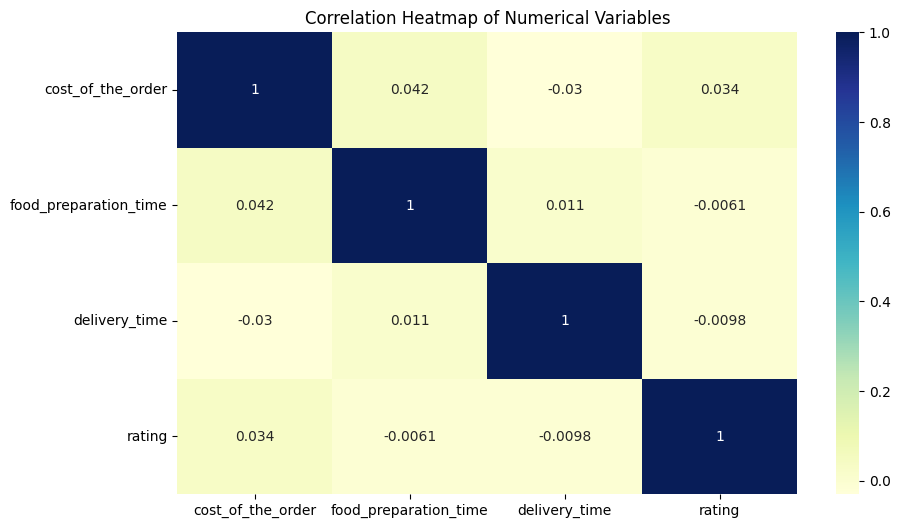

```python
# Plot the correlation heatmap for numerical variables showing the ability of multivariate analysis
plt.figure(figsize=(10, 6))
sns.heatmap(data[['cost_of_the_order', 'food_preparation_time', 'delivery_time', 'rating']].corr(), annot=True, cmap='YlGnBu')
plt.title('Correlation Heatmap of Numerical Variables')
plt.show()
```

#### Observations from Multivariate Analysis:

**Correlation Heatmap:**

- There is a weak positive correlation between `cost_of_the_order` and `food_preparation_time`, suggesting that more expensive orders might take slightly longer to prepare.
- There is also a weak positive correlation between `food_preparation_time` and `delivery_time`, indicating that longer preparation times might lead to slightly longer delivery times.
- There are no strong correlations observed between `rating` and any of the other numerical variables, which suggests that rating is likely influenced by factors not captured in these numerical columns.

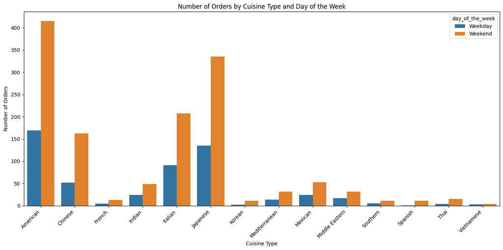

```python
# Plot the boxplot for numerical variable 'number_of_orders' and its relationship with 'day_of_the_week', 'cuisine_type' showing the ability of multivariate analysis

# Calculate the number of orders for each cuisine type on weekdays and weekends
cuisine_day_orders = data.groupby(['day_of_the_week', 'cuisine_type']).size().reset_index(name='number_of_orders')

# Plot the grouped bar plot
plt.figure(figsize=(14, 7))
sns.barplot(data=cuisine_day_orders, x='cuisine_type', y='number_of_orders', hue='day_of_the_week')
plt.title('Number of Orders by Cuisine Type and Day of the Week')
plt.xlabel('Cuisine Type')
plt.ylabel('Number of Orders')
plt.xticks(rotation=45, ha='right')
plt.tight_layout()
plt.show()
```

#### Observations from Multivariate Analysis:

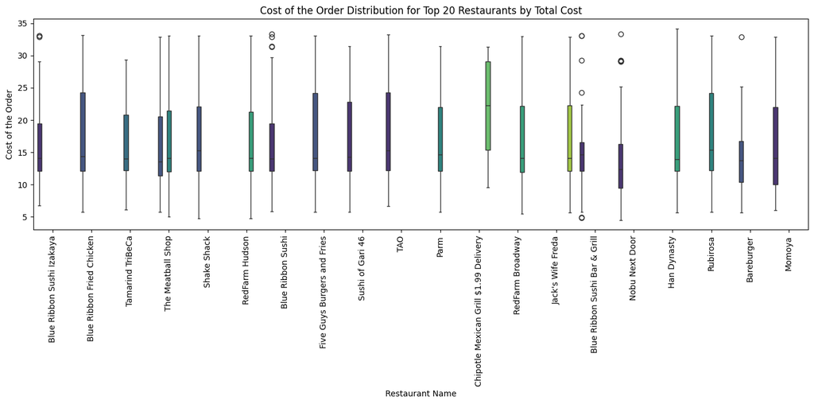

```python
# Plot the boxplot for numerical variable 'cost_of_the_order' and its relationship with categorical variables 'restaurant name', 'cuisine_type' showing the ability of multivariate analysis

# Calculate the total cost of orders for each restaurant
restaurant_total_cost = data.groupby('restaurant_name')['cost_of_the_order'].sum().reset_index()

# Identify the top 20 restaurants based on total cost
top_20_restaurants_by_cost = restaurant_total_cost.nlargest(20, 'cost_of_the_order')['restaurant_name']

# Filter the original data to include only orders from the top 20 restaurants
top_20_data = data[data['restaurant_name'].isin(top_20_restaurants_by_cost)]

# Create a box plot
plt.figure(figsize=(14, 7))
sns.boxplot(data=top_20_data, x='restaurant_name', y='cost_of_the_order', hue='cuisine_type', palette='viridis', legend=False)
plt.title('Cost of the Order Distribution for Top 20 Restaurants by Total Cost')
plt.xlabel('Restaurant Name')
plt.ylabel('Cost of the Order')
plt.xticks(rotation=90)
plt.tight_layout()
plt.show()
```

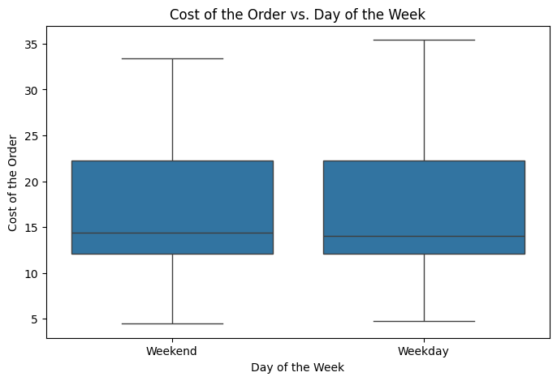

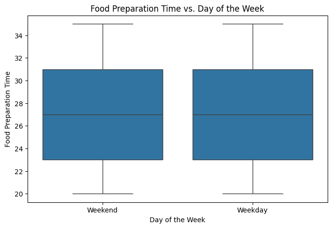

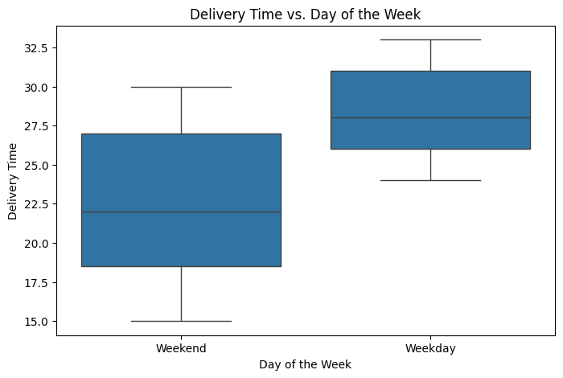

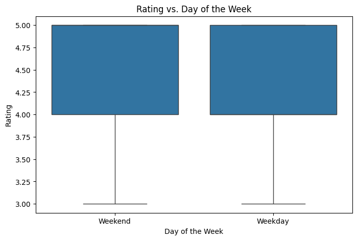

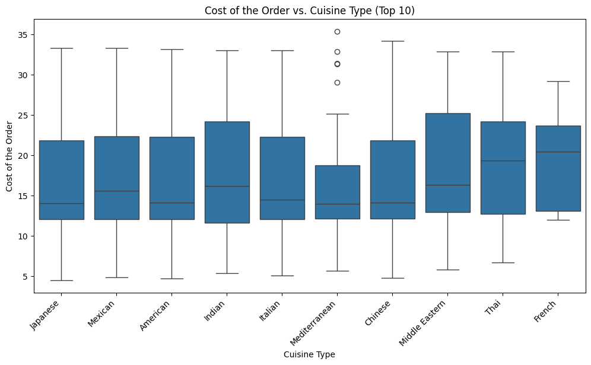

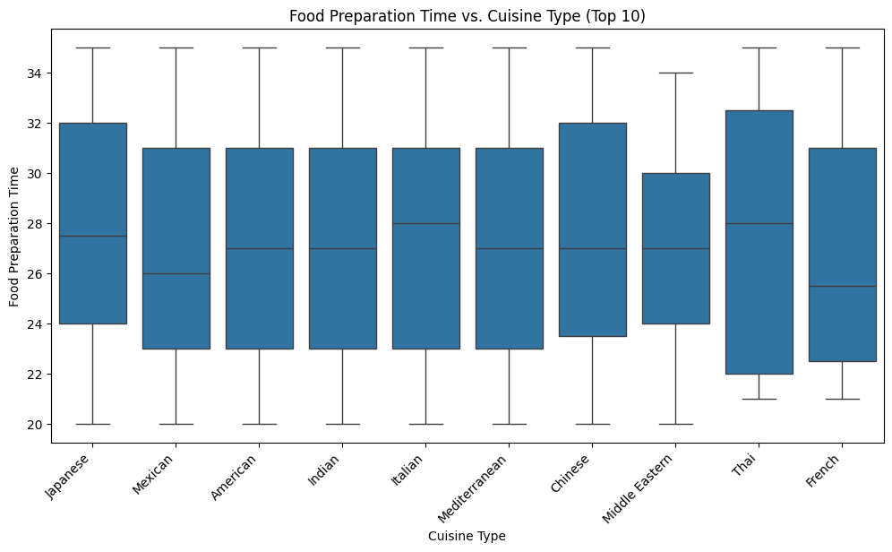

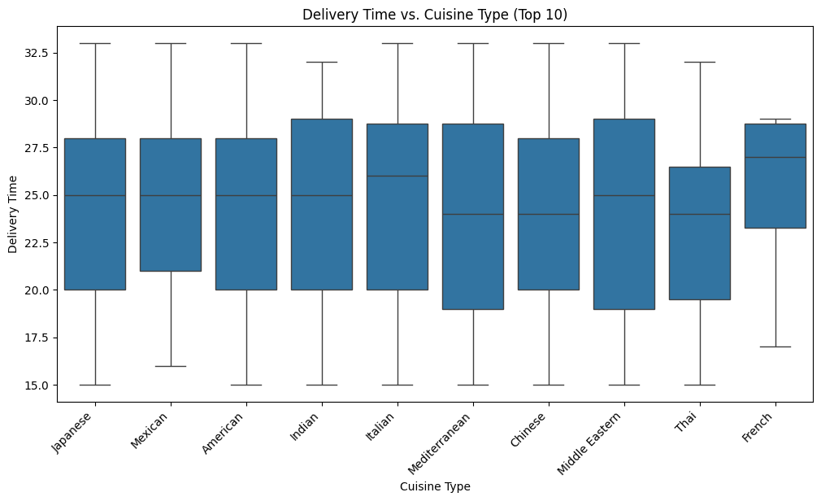

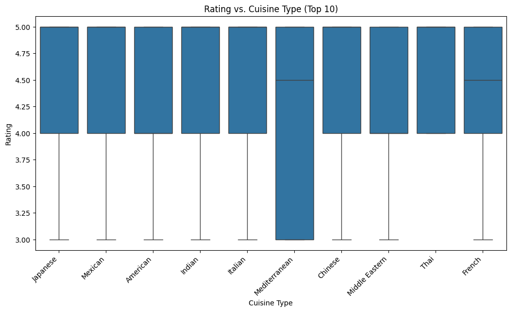

```python
# Explore the relationship between numerical and categorical variables using boxplots.
# We are focusing on bivariate analysis here, by considering 2 columns for varied combination of analysis that will help in adding value for business analysis

# Cost of the order vs. Day of the week
plt.figure(figsize=(8, 5))
sns.boxplot(x='day_of_the_week', y='cost_of_the_order', data=data)
plt.title('Cost of the Order vs. Day of the Week')
plt.xlabel('Day of the Week')
plt.ylabel('Cost of the Order')
plt.show()

# Food preparation time vs. Day of the week
plt.figure(figsize=(8, 5))
sns.boxplot(x='day_of_the_week', y='food_preparation_time', data=data)
plt.title('Food Preparation Time vs. Day of the Week')
plt.xlabel('Day of the Week')
plt.ylabel('Food Preparation Time')
plt.show()

# Delivery time vs. Day of the week
plt.figure(figsize=(8, 5))
sns.boxplot(x='day_of_the_week', y='delivery_time', data=data)
plt.title('Delivery Time vs. Day of the Week')
plt.xlabel('Day of the Week')
plt.ylabel('Delivery Time')
plt.show()

# Rating vs. Day of the week
plt.figure(figsize=(8, 5))
sns.boxplot(x='day_of_the_week', y='rating', data=data)
plt.title('Rating vs. Day of the Week')
plt.xlabel('Day of the Week')
plt.ylabel('Rating')
plt.show()

# Cost of the order vs. Cuisine Type (Top 10 cuisines)
plt.figure(figsize=(12, 6))
top_10_cuisines = data['cuisine_type'].value_counts().nlargest(10).index
sns.boxplot(x='cuisine_type', y='cost_of_the_order', data=data[data['cuisine_type'].isin(top_10_cuisines)])
plt.title('Cost of the Order vs. Cuisine Type (Top 10)')
plt.xlabel('Cuisine Type')
plt.ylabel('Cost of the Order')
plt.xticks(rotation=45, ha='right')
plt.show()

# Food preparation time vs. Cuisine Type (Top 10 cuisines)
plt.figure(figsize=(12, 6))
sns.boxplot(x='cuisine_type', y='food_preparation_time', data=data[data['cuisine_type'].isin(top_10_cuisines)])
plt.title('Food Preparation Time vs. Cuisine Type (Top 10)')
plt.xlabel('Cuisine Type')
plt.ylabel('Food Preparation Time')
plt.xticks(rotation=45, ha='right')
plt.show()

# Delivery time vs. Cuisine Type (Top 10 cuisines)
plt.figure(figsize=(12, 6))
sns.boxplot(x='cuisine_type', y='delivery_time', data=data[data['cuisine_type'].isin(top_10_cuisines)])
plt.title('Delivery Time vs. Cuisine Type (Top 10)')
plt.xlabel('Cuisine Type')
plt.ylabel('Delivery Time')
plt.xticks(rotation=45, ha='right')
plt.show()

# Rating vs. Cuisine Type (Top 10 cuisines)
plt.figure(figsize=(12, 6))
sns.boxplot(x='cuisine_type', y='rating', data=data[data['cuisine_type'].isin(top_10_cuisines)])
plt.title('Rating vs. Cuisine Type (Top 10)')
plt.xlabel('Cuisine Type')
plt.ylabel('Rating')
plt.xticks(rotation=45, ha='right')
plt.show()
```

### **Question 13:** The company wants to provide a promotional offer in the advertisement of the restaurants. The condition to get the offer is that the restaurants must have a rating count of more than 50 and the average rating should be greater than 4. Find the restaurants fulfilling the criteria to get the promotional offer. [3 marks]

```python
###This code identifies restaurants with over 50 ratings and an average rating above 4 for promotional eligibility.
# Filter out orders with no rating
rated_data = data.dropna(subset=['rating'])

# Group by restaurant and calculate rating count and average rating
restaurant_ratings = rated_data.groupby('restaurant_name')['rating'].agg(['count', 'mean']).reset_index()

# Filter for restaurants that meet the promotional offer criteria
promotional_restaurants = restaurant_ratings[(restaurant_ratings['count'] > 50) & (restaurant_ratings['mean'] > 4)]

# Display the restaurants fulfilling the criteria
print("Restaurants fulfilling the promotional offer criteria:")
display(promotional_restaurants)
```

```
Restaurants fulfilling the promotional offer criteria:
```

|  | restaurant_name | count | mean |
| --- | --- | --- | --- |
| 16 | Blue Ribbon Fried Chicken | 64 | 4.328125 |
| 17 | Blue Ribbon Sushi | 73 | 4.219178 |
| 117 | Shake Shack | 133 | 4.278195 |
| 132 | The Meatball Shop | 84 | 4.511905 |

#### Observations:

**Highest Rated**:The Meatball Shop leads with the highest average rating of 4.51, suggesting strong customer satisfaction.

**Most Reviewed**:Shake Shack has the highest number of reviews (133), indicating high popularity or foot traffic.

**Blue Ribbon Comparison**:Blue Ribbon Fried Chicken slightly outperforms Blue Ribbon Sushi in average rating (4.33 vs 4.22) despite having fewer reviews.

### **Question 14:** The company charges the restaurant 25% on the orders having cost greater than 20 dollars and 15% on the orders having cost greater than 5 dollars. Find the net revenue generated by the company across all orders. [3 marks]

```python
###This code calculates total revenue by applying tiered surcharges to orders based on their cost.

#Applies the surcharge logic directly to each order.
#Sums the result to get total revenue.
#No extra columns or data modifications—just the final number.

# Calculate revenue for orders > $20 (25%)
revenue_fororders_gt_20 = (data[data['cost_of_the_order'] > 20]['cost_of_the_order'] * 0.25).sum()

# Calculate revenue for orders > $5 and <= $20 (15%)
revenue_fororders_gt_5_le_20 = (data[(data['cost_of_the_order'] > 5) & (data['cost_of_the_order'] <= 20)]['cost_of_the_order'] * 0.15).sum()

# Calculate net revenue
net_revenue = revenue_fororders_gt_20 + revenue_fororders_gt_5_le_20

print(f"The net revenue generated by the company across all orders is: ${net_revenue:.2f}")
```

```
The net revenue generated by the company across all orders is: $6166.30
```

#### Observations:

**The company generated $6,166.30 in net revenue solely from surcharges applied to qualifying orders, excluding base order costs**.

**This figure reflects the effectiveness of the tiered commission model**, capturing income from orders above $5 and $20 at 15% and 25% rates respectively.

### **Question 15:** The company wants to analyze the total time required to deliver the food. What percentage of orders take more than 60 minutes to get delivered from the time the order is placed? (The food has to be prepared and then delivered.) [2 marks]

```python
#This code calculates the percentage of orders where the combined food preparation and delivery time exceeds 60 minutes

# Count the number of orders where food preparation time + delivery time is greater than 60 minutes
orders_gt_60_minutes_preptime = data[(data['food_preparation_time'] + data['delivery_time']) > 60].shape[0]

# Calculate the total number of orders
total_orders = data.shape[0]

# Calculate the percentage of orders that took more than 60 minutes
percentage_gt_60_minutes_preptime = (orders_gt_60_minutes_preptime / total_orders) * 100

print(f"Percentage of orders taking more than 60 minutes to deliver: {percentage_gt_60_minutes_preptime:.2f}%")
```

```
Percentage of orders taking more than 60 minutes to deliver: 10.54%
```

#### Observations:

**Operational Efficiency** **Majority of orders are timely**: Nearly 90% of orders are delivered within an hour, suggesting overall efficiency in the delivery pipeline.

**Only 10.54% of the orders take more than 60 minutes** to deliver from the time the food orders is placed

### **Question 16:** The company wants to analyze the delivery time of the orders on weekdays and weekends. How does the mean delivery time vary during weekdays and weekends? [2 marks]

```python
#This code calculates and displays the average delivery time for each day of the week using grouped order data

# Group data by day of the week and calculate the mean delivery time
mean_delivery_time_by_day = data.groupby('day_of_the_week')['delivery_time'].mean()

# Display the mean delivery time for weekdays and weekends
print("Mean delivery time (in minutes) by day of the week:")
print(mean_delivery_time_by_day)
```

```
Mean delivery time (in minutes) by day of the week:
day_of_the_week
Weekday    28.340037
Weekend    22.470022
Name: delivery_time, dtype: float64
```

#### Observations:

**Delivery time insights:**

**Faster weekend deliveries**: The average delivery time on weekends is approximately 22.47 minutes, which is 5.87 minutes shorter than on weekdays.

**Weekday delays**: With a mean of 28.34 minutes, weekday deliveries may be affected by higher traffic, workday congestion, or increased order volume during peak hours.

### Conclusion and Recommendations

### **Question 17:** What are your conclusions from the analysis? What recommendations would you like to share to help improve the business? (You can use cuisine type and feedback ratings to drive your business recommendations.) [6 marks]

### Observations:

- The analysis uncovered valuable insights into both customer preferences and operational performance.
- Weekend orders tend to surge, with American cuisine emerging as the top choice among diners.
- Shake Shack stands out as the most frequently ordered-from restaurant, indicating its strong popularity.
- A notable share of orders lack customer ratings, suggesting room for improving feedback collection.
- Delivery efficiency improves on weekends, with faster turnaround times compared to weekdays.
- Most orders are fulfilled within an hour, reflecting a generally prompt delivery service.
- Multiple restaurants qualify for promotional offers, having surpassed thresholds for both rating volume and average satisfaction.

### Recommendations:

- Since American restaurants receive the highest order volume, partnering with more highly rated American eateries could further boost customer engagement and sales.
- To increase orders from underrepresented cuisines such as French, Vietnamese, and Korean, the platform can spotlight restaurants offering competitive pricing and efficient delivery times to attract new customers.
- Introducing seasonal promotions focused on American cuisine could drive substantial revenue, leveraging its popularity during peak periods.
- Enhancing delivery transparency by providing real-time order updates can help manage customer expectations and encourage more timely ordering decisions.